# Using Stan to Estimate Bayesian Models

## Assessing Convergence

The `RStan` package also includes a number of useful functions for diagnosing convergence and ensuring that we’re sampling from the posterior distribution. We can use `traceplot()` to evaluate the mixing of the chains. If we set `inc_warmup = T`, then we can view all samples for each parameter, giving us increased confidence that we have fully explored the parameter space.

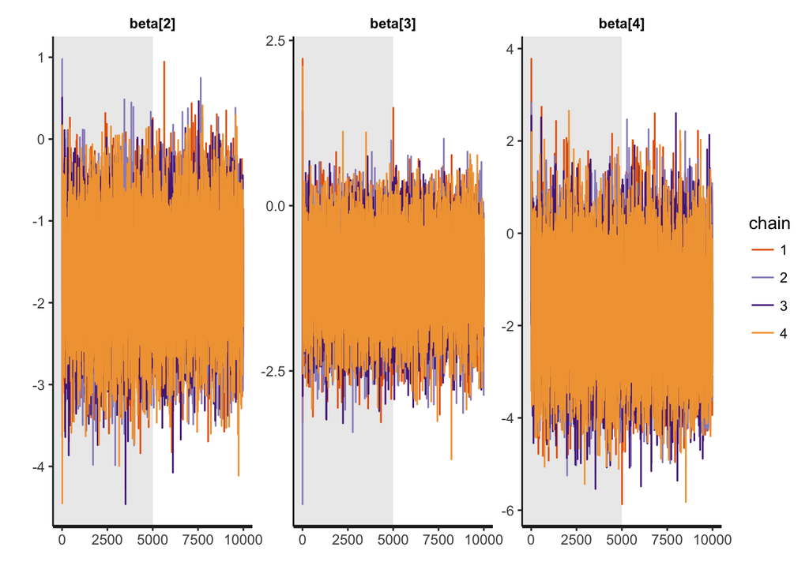

```r
traceplot(m1, pars = paste('beta[', 2:4, ']', sep = ''), inc_warmup = T)
```

We can also evaluate the autocorrelation between samples for each parameter at different lags. Given the nature of Markov chains, there *has* to be some autocorrelation at the first lag, but we want to see a sharp drop off as the lags increase. Since we are performing this operation on multiple chains, these results are the average autocorrelation values from all four chains.

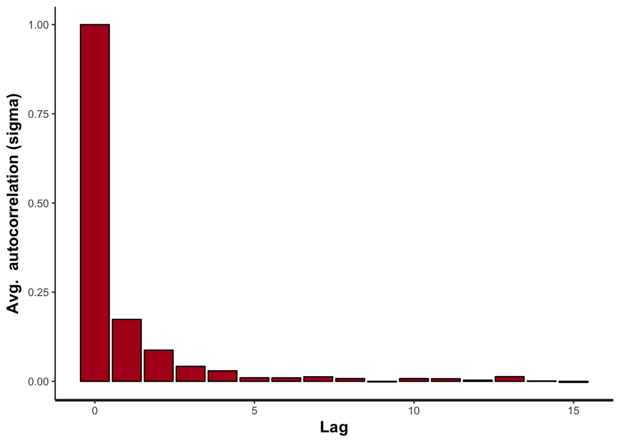

```r
stan_ac(m1, pars = 'sigma', lags = 15)
```

What if we want a plot of the potential scale reduction factor $\hat{R}$ at each iteration of the sampler? Unfortunately, `rstan` doesn’t include a builtin function to produce this plot. Fortunately, it does provide an incredibly easy way to convert a `stanfit` object to a `coda` object using the `As.mcmc.list()` function.

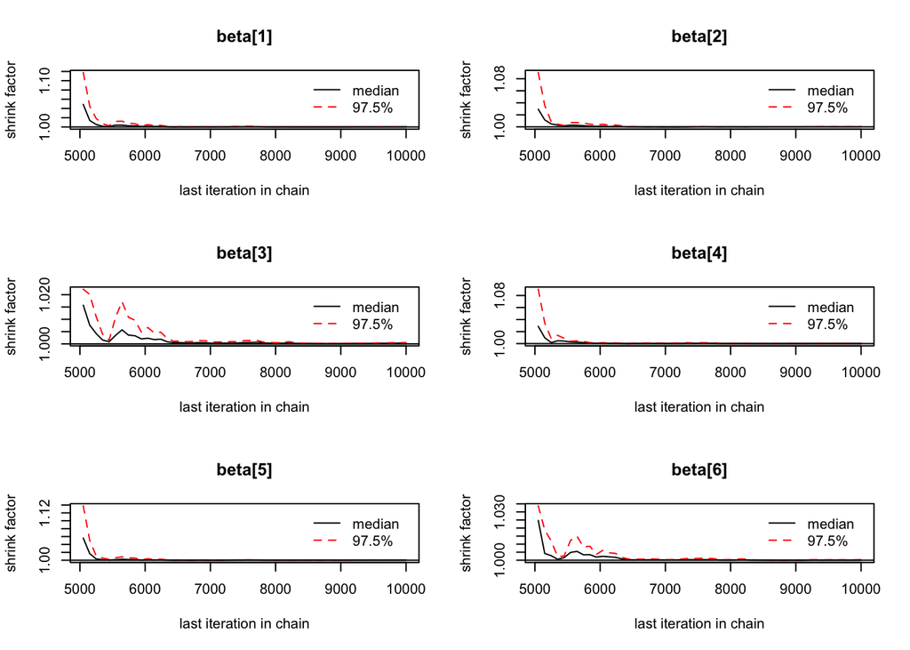

```r
coda::gelman.plot(As.mcmc.list(m1, pars = 'beta'), autoburnin = F)
```

## Presenting Results

Now that we’re confident that our samples are actually drawn from the posterior distribution, we need to communicate the information contained in them to our readers. Typing `m1` will print the mean, Monte Carlo standard errors, standard deviation, various percentiles of the samples, the effective sample size, and the $\hat{R}$ for each parameter, as well as some of the sampler parameters.

To save the parameter estimate summaries to an object, we use the `summary()` function. If we assign an object using just `summary(m1)`, it will create a list, with the first entry `summary` containing the matrix of parameter estimates we just saw, and the second entry `c_summary` containing a list of matrices for each individual chain. Since we’re confident that our chains mixed well, we want to do inference on all of them merged together, so our call to `summary()` should be followed by the `$summary` index reference to access the posterior samples from all chains merged together.

```r
# rename parameters in stan model with predictor names
names(m1)[1:6] <- colnames(predictors)

# extract regression parameters
m1_sum <- summary(m1, pars = c('beta', 'sigma'))$summary
kable(m1_sum)
```

|  | mean | se_mean | sd | 2.5% | 25% | 50% | 75% | 98% | n_eff | Rhat |
| --- | --- | --- | --- | --- | --- | --- | --- | --- | --- | --- |
| (Intercept) | 13.0 | 0.01 | 1.01 | 11.0 | 12.3 | 13.0 | 13.7 | 14.96 | 5265 | 1 |
| scale(hetero) | -1.6 | 0.01 | 0.56 | -2.7 | -2.0 | -1.6 | -1.3 | -0.55 | 9057 | 1 |
| scale(mobility) | -1.1 | 0.01 | 0.55 | -2.2 | -1.4 | -1.1 | -0.7 | 0.00 | 6408 | 1 |
| as.factor(region)MW | -1.7 | 0.01 | 1.03 | -3.7 | -2.4 | -1.7 | -1.0 | 0.39 | 6823 | 1 |
| as.factor(region)S | -3.0 | 0.02 | 1.69 | -6.3 | -4.2 | -3.0 | -1.9 | 0.34 | 5452 | 1 |
| as.factor(region)W | -2.6 | 0.02 | 1.53 | -5.5 | -3.6 | -2.6 | -1.5 | 0.44 | 6465 | 1 |
| sigma | 2.2 | 0.00 | 0.26 | 1.7 | 2.0 | 2.2 | 2.3 | 2.76 | 11482 | 1 |

Because we’re not interested in stars, this table isn’t super informative for the reader. As Bayesians we want to know where the majority of a parameter’s posterior distribution falls relative to zero, which is much more easily assessed graphically. We can plot the results from our model using the `plot()` command on a `stanfit`, which object will produce a dotplot of point estimates for parameters with credible interval bars.

```
## ci_level: 0.8 (80% intervals)
```

```
## outer_level: 0.95 (95% intervals)
```

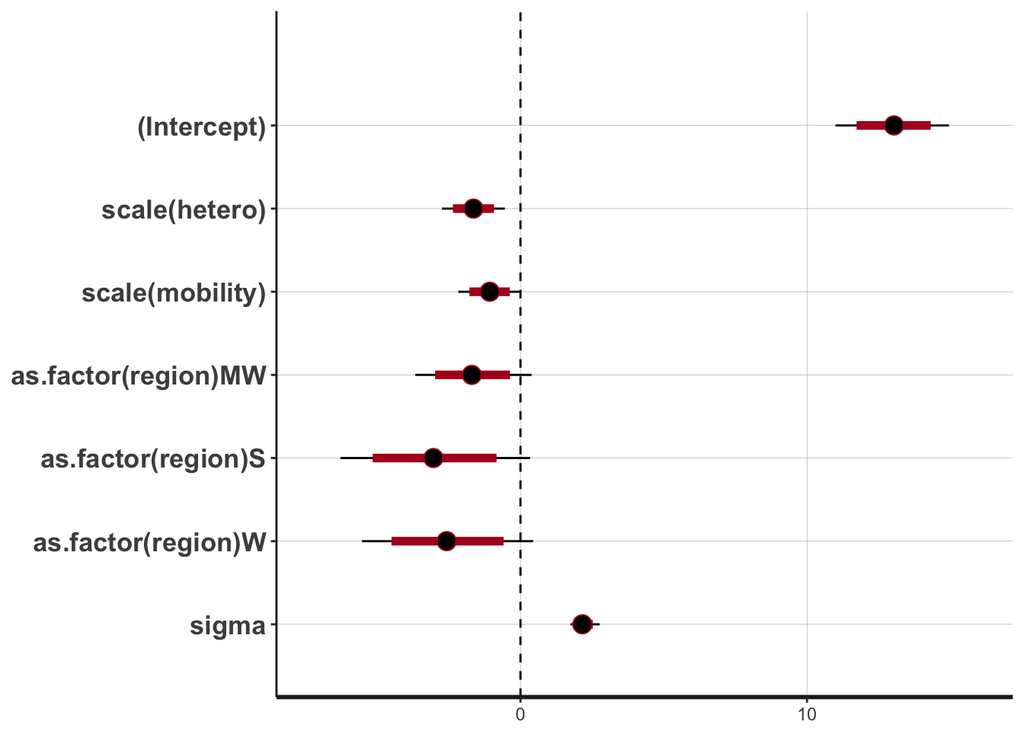

```r
plot(m1, pars = c('beta', 'sigma')) + geom_vline(xintercept = 0, linetype = 2)
```

The `plot()` command is actually a wrapper to the `stan_plot()` command, which has arguments unique to `stanfit` objects. To see more information about the various Stan plots available, type `` ?`plot,stanfit-method` ``.

If we want to view the actual distribution of posterior samples for a given parameter, rather than just credible intervals, we can use the `stan_dens()` command to generate density plots. We can use the `pars` argument to limit the results to specific parameters. This is especially useful if we have lots of hierarchical parameters, or if we are estimating many latent variables and a plot of all of them would be unreadable.

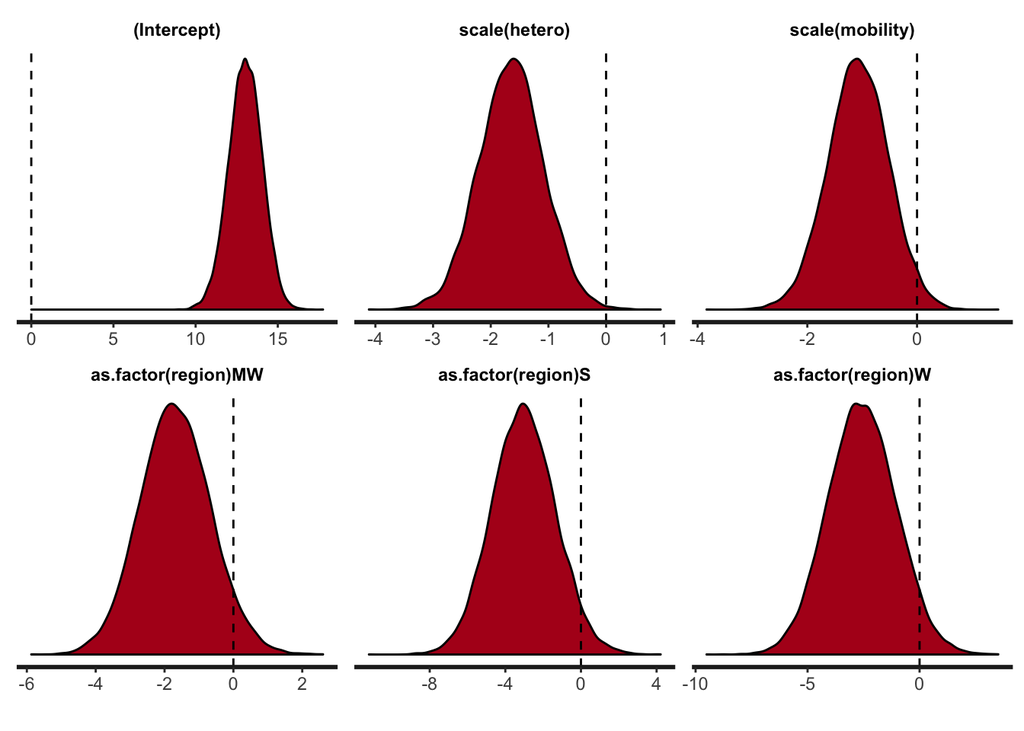

```r
stan_dens(m1, pars = 'beta') + geom_vline(xintercept = 0, linetype = 2)
```

Notice that we can still use `beta` as an argument to `pars`, even though we renamed our parameters above. This is because Stan stores the names of each parameter object separately from the names accessed by `names()`. You can see this for yourself by typing `m1@model_pars`. If you rename parameters in a `stanfit` object, you can refer to entire vectors of parameters by their original names, but not individually. What this means is you can use `pars = 'beta'` to access *all* of the coefficient estimates, but you can’t use `pars = 'beta[3]'` to access the coefficient estimate for mobility.

For many Stan plots, we can use the `separate_chains = T` argument to view the resulting figure for all individual chains, rather than the averaged output.

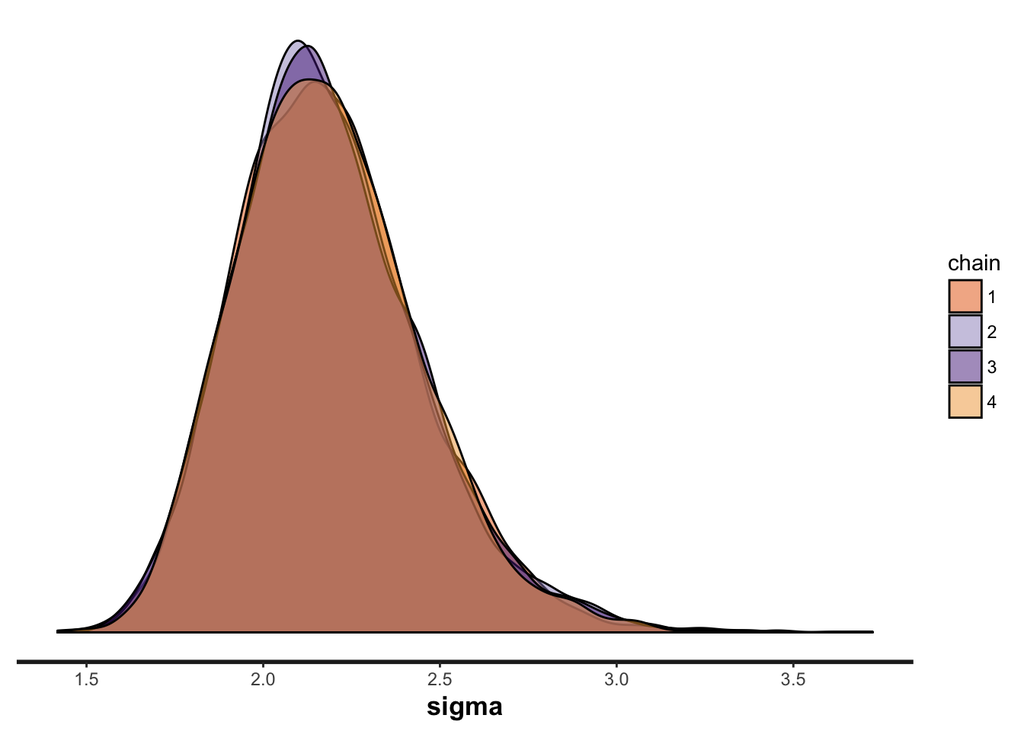

```r
stan_dens(m1, pars = 'sigma', separate_chains = T)
```

We can also generate scatterplots of the correlation between parameters using the `stan_scat()` command. If we have a complex model that generates a lot of divergent transitions during sampling (this is common in hierarchical models), we might use the `pairs()` function to identify the responsible parameters which could be candidates for reparameterization.

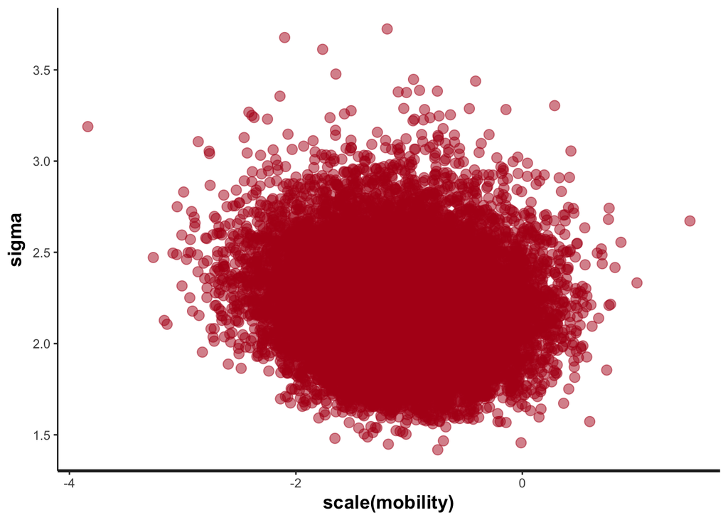

```r
stan_scat(m1, pars = c('scale(mobility)', 'sigma'))
```

## Accessing Samples

If we want to directly work with the samples from our model like with JAGS, we can do that as well. To extract all of the samples for a given parameter, we use the `extract()` function, which returns a list of the samples for each parameter.

```r
samps <- extract(m1, pars = c('beta', 'sigma'))
str(samps)
```

```
## List of 2
##  $ beta : num [1:20000, 1:6] 13.5 12.2 13.1 13.6 12.4 ...
##   ..- attr(*, "dimnames")=List of 2
##   .. ..$ iterations: NULL
##   .. ..$           : NULL
##  $ sigma: num [1:20000(1d)] 2.11 2.15 1.96 2.13 2.12 ...
##   ..- attr(*, "dimnames")=List of 1
##   .. ..$ iterations: NULL
```

```r
beta_samps <- samps$beta
```

Once we’ve extracted our samples from the posterior distribution, we can plot them just like with samples from JAGS. This approach is also useful if you want more control over the graphical parameters of your figures than the builtin Stan plotting functions provide.

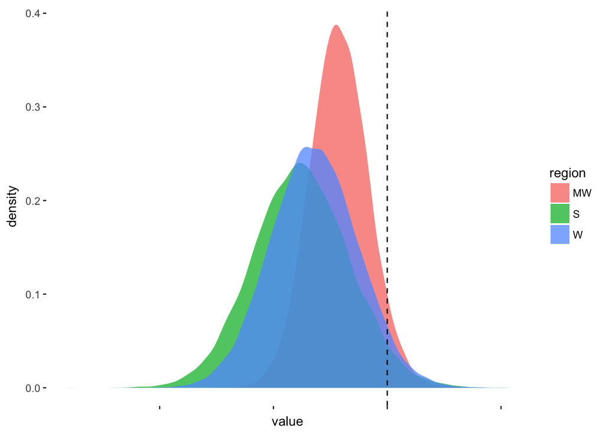

```r
# get samples for region dummies
beta_samps <- as.data.frame(beta_samps[, 4:6])

# drop the 'as.factor(region)' from names for cleaner legend
names(beta_samps) <- gsub('as\\.factor\\(region\\)', '', colnames(predictors[, 4:6]))

# prepare data for ggplot
beta_samps <- tidyr::gather(beta_samps)

# plot, grouping by region dummy, add line at 0, and drop x axis label
ggplot(data = beta_samps, aes(x = value, fill = key)) +
  geom_density(alpha = .75, linetype = 0) +
  geom_vline(xintercept = 0, linetype = 2) +
  guides(fill = guide_legend(title = 'region')) +
  theme_bw() +
  theme(plot.title = element_text(hjust = 0.5),
        axis.text.x  = element_blank(),
        legend.position = 'right',
        plot.background = element_blank(),
        panel.grid.minor = element_blank(),
        panel.grid.major = element_blank(),
        panel.border = element_blank())
```

The `ggridges` package provides a way to create ridge plots which put multiple density plots on the same graph with a shared axis, allowing the viewer to easily compare entire posterior distributions, instead of just point estimates and summaries of uncertainty. This approach also lets the viewer visually assess convergence between chains.

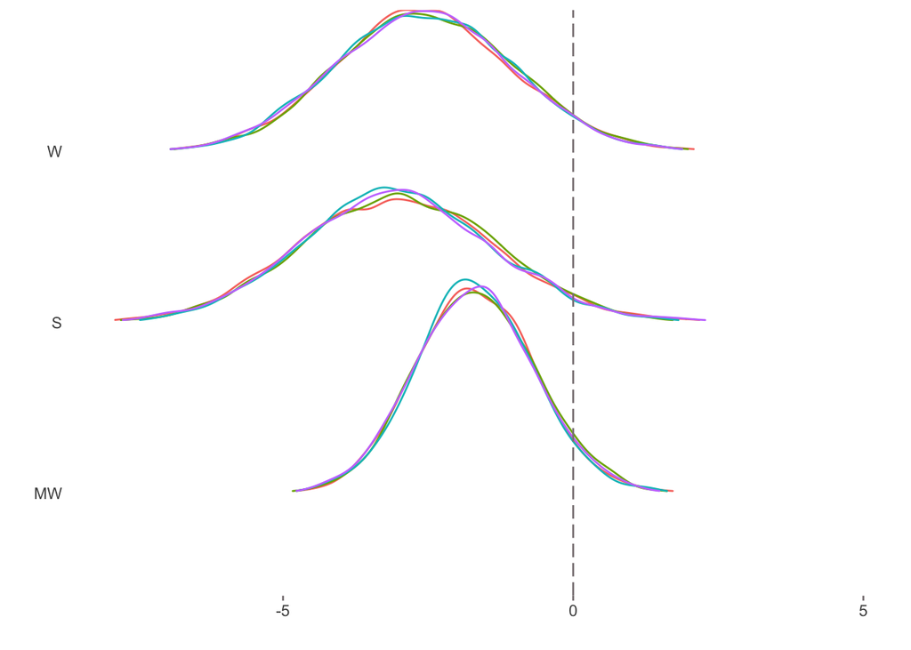

```r
# ridge plots
library(ggridges)

# create ggs objet for ridge plot
ridge_ggs <- ggmcmc::ggs(m1, family = 'beta')

# keep only last 3 beta parameters, which are our region dummies
ridge_ggs <- ridge_ggs[grepl('[4-6]', ridge_ggs$Parameter), ]

# ridge plot; east as refernce category
ggplot(ridge_ggs, aes(x = value, y = Parameter, height = ..density.., color = as.factor(Chain))) +
  geom_density_ridges(fill = NA, rel_min_height = .01, scale = 1.25, show.legend = F) +
  geom_vline(xintercept = 0, linetype = 5, col = 'lavenderblush4') +
  labs(x = '', y = '') +
  theme_bw() +
  scale_y_discrete(labels = c('MW', 'S', 'W')) +
  coord_cartesian(xlim = c(-8, 5)) +
  theme(plot.background = element_blank(),
        panel.grid.minor = element_blank(),
        panel.grid.major = element_blank(),
        panel.border = element_blank(),
        axis.ticks.y = element_blank(),
        axis.ticks.x = element_line(color = 'lavenderblush4'))
```

We might also want to extract samples if we are estimating a glm and want to generate predicted probabilities. One of the advantages of Bayes is that instead of having to assume that our coefficient estimates are drawn from a multivariate normal distribution, and then generating simulated coefficients from that distribution, we can instead simply take the last thousand draws for each parameter and use those to calculate predicted probabilities.

Extracting samples can also let us conduct model fit checks such as residual plots.

```r
# create dataframe for ggplot
df_resid <- data.frame(y = moral,
                       y_hat = summary(m1, pars = 'y_hat')$summary[, 'mean'],
                       residual = summary(m1, pars = 'resid')$summary[, 'mean'])

# plot predicted values against observed values
pred_plot <- ggplot(df_resid, aes(x = y_hat, y = y, color = residual)) +
  geom_point(alpha = .75) +
  scale_color_continuous(low = 'darkred', high = 'lightsalmon') +
  geom_abline(slope = 1, intercept = 0) +
  theme_bw() +
  theme(legend.position = 'right',
        plot.background = element_blank(),
        panel.grid.minor = element_blank(),
        panel.grid.major = element_blank(),
        panel.border = element_blank())

# plot residuals against predicted values
resid_plot <- ggplot(df_resid , aes(x = y_hat, y = residual, color = residual)) +
  geom_point(alpha = .75) +
  scale_color_continuous(low = 'darkred', high = 'lightsalmon') +
  geom_hline(yintercept = 0) +
  theme_bw() +
  theme(legend.position = 'right',
        plot.background = element_blank(),
        panel.grid.minor = element_blank(),
        panel.grid.major = element_blank(),
        panel.border = element_blank())

# arrange side by side as interactive plotly plots
plotly::subplot(pred_plot, resid_plot, nrows = 1)
```

[interactive chart not shown]